# Team12_MLII_TP1

Haider Ali, Walker Campbell, Trenton Carpenter, Ian Dors,

2/6/2021

Team 12

7.8.1 Polynomial Regression and Step Functions

```r
rm(list=ls())

library(ISLR)
attach(Wage)
head(Wage)
```

```
##        year age           maritl     race       education             region
## 231655 2006  18 1. Never Married 1. White    1. < HS Grad 2. Middle Atlantic
## 86582  2004  24 1. Never Married 1. White 4. College Grad 2. Middle Atlantic
## 161300 2003  45       2. Married 1. White 3. Some College 2. Middle Atlantic
## 155159 2003  43       2. Married 3. Asian 4. College Grad 2. Middle Atlantic
## 11443  2005  50      4. Divorced 1. White      2. HS Grad 2. Middle Atlantic
## 376662 2008  54       2. Married 1. White 4. College Grad 2. Middle Atlantic
##              jobclass         health health_ins  logwage      wage
## 231655  1. Industrial      1. <=Good      2. No 4.318063  75.04315
## 86582  2. Information 2. >=Very Good      2. No 4.255273  70.47602
## 161300  1. Industrial      1. <=Good     1. Yes 4.875061 130.98218
## 155159 2. Information 2. >=Very Good     1. Yes 5.041393 154.68529
## 11443  2. Information      1. <=Good     1. Yes 4.318063  75.04315
## 376662 2. Information 2. >=Very Good     1. Yes 4.845098 127.11574
```

First we clear our environment. Next, load ‘ISLR’, attach our data set ‘Wage’ and view the top six rows.

3,000 males from Mid-Atlantic, 11 variables

year: -Year that wage information was recorded

age: -Age of worker

maritl: -A factor with levels 1. Never Married 2. Married 3. Widowed 4. Divorced and 5. Separated indicating marital status

race: -A factor with levels 1. White 2. Black 3. Asian and 4. Other indicating race

education: -A factor with levels 1. < HS Grad 2. HS Grad 3. Some College 4. College Grad and 5. Advanced Degree indicating education level

region: -Region of the country (mid-atlantic only)

jobclass: -A factor with levels 1. Industrial and 2. Information indicating type of job

health: -A factor with levels 1. <=Good and 2. >=Very Good indicating health level of worker

health_ins: -A factor with levels 1. Yes and 2. No indicating whether worker has health insurance

logwage: -Log of workers wage

***wage: -Workers raw wage

Data was manually assembled by Steve Miller, of Open BI (www.openbi.com), from the March 2011 Supplement to Current Population Survey data.

```r
fit = lm(wage~poly(age,4), data=Wage)
coef(summary(fit))
```

```
##                 Estimate Std. Error    t value     Pr(>|t|)
## (Intercept)    111.70361  0.7287409 153.283015 0.000000e+00
## poly(age, 4)1  447.06785 39.9147851  11.200558 1.484604e-28
## poly(age, 4)2 -478.31581 39.9147851 -11.983424 2.355831e-32
## poly(age, 4)3  125.52169 39.9147851   3.144742 1.678622e-03
## poly(age, 4)4  -77.91118 39.9147851  -1.951938 5.103865e-02
```

Use ‘lm’ function to create a linear model that predicts wage using a fourth-degree polynomial of age. *Each column in returned matrix is a linear combination of the variables age, age^2, age^3, age^4.???* Contains four features: age, age^2, age^3, age^4.

[output not shown]

This is the direct way to obtain each degree. Notice the coefficients are different but the fitted values in the end will not vary .

```r
fit2a = lm(wage~age+I(age^2)+I(age^3)+I(age^4), data=Wage)
coef(fit2a)
```

```
##   (Intercept)           age      I(age^2)      I(age^3)      I(age^4)
## -1.841542e+02  2.124552e+01 -5.638593e-01  6.810688e-03 -3.203830e-05
```

I() isolates features to create the same estimates as using ‘raw = True’.

```r
fit2b = lm(wage~cbind(age,age^2,age^3,age ^4), data=Wage)
coef(fit2b)
```

```
##                        (Intercept) cbind(age, age^2, age^3, age^4)age
##                      -1.841542e+02                       2.124552e+01
##    cbind(age, age^2, age^3, age^4)    cbind(age, age^2, age^3, age^4)
##                      -5.638593e-01                       6.810688e-03
##    cbind(age, age^2, age^3, age^4)
##                      -3.203830e-05
```

A more compact way compared to using the ‘I()’. ‘cbind()’ functions as a wrapper producing the same results.

```r
agelims  = range(age)
age.grid = seq(from=agelims[1], to=agelims[2])
preds    = predict(fit, newdata=list(age=age.grid), se=TRUE)
se.bands = cbind(preds$fit+2*preds$se.fit, preds$fit-2*preds$se.fit)
```

Get the range of all ages and create a list of every age between the range. Create predictions based off of the original orthogonal model $lm(wage~poly(age,4)$. Then we create our 95% confidence interval using the standard errors of our predictions.

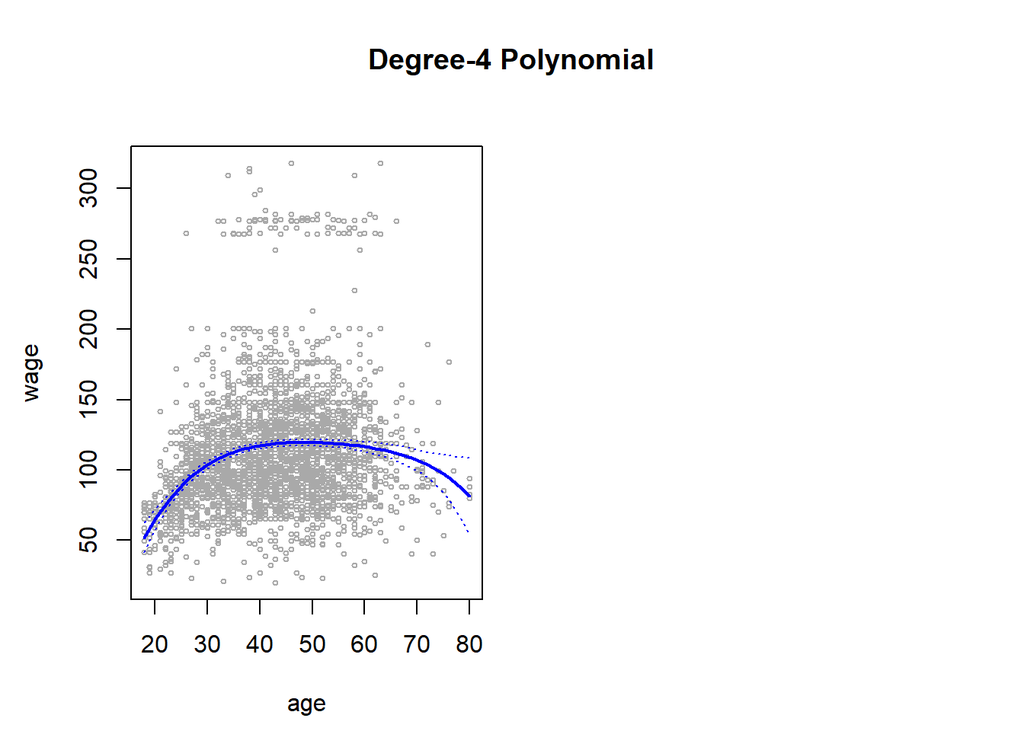

```r
par(mfrow=c(1,2), mar=c(4.5,4.5,1,1), oma=c(0,0,4,0))
plot(age, wage, xlim=agelims, cex =.5, col="darkgrey ")
title("Degree-4 Polynomial",outer=T)
lines(age.grid, preds$fit, lwd=2, col="blue")
matlines(age.grid, se.bands, lwd=1, col=" blue", lty=3)
```

Plotting Age vs Wage using the original fit model (orthogonal). Solid Blue is predicted Wage, while the dotted upper and lower blue lines are the bounds of the 95% confidence interval.

```r
preds2 = predict(fit2, newdata=list(age=age.grid), se=TRUE)
max(abs(preds$fit-preds2$fit))
```

```
## [1] 7.81597e-11
```

Using the non-orthogonal model, fit2 $lm(wage~poly(age,4,raw=T), data=Wage)$, we can see the fitted values are nearly identical (almost 0).

```r
fit.1=lm(wage~age ,data=Wage)
fit.2=lm(wage~poly(age ,2),data=Wage)
fit.3=lm(wage~poly(age ,3),data=Wage)
fit.4=lm(wage~poly(age ,4),data=Wage)
fit.5=lm(wage~poly(age ,5),data=Wage)
anova(fit.1,fit.2,fit.3,fit.4,fit.5)
```

```
## Analysis of Variance Table
##
## Model 1: wage ~ age
## Model 2: wage ~ poly(age, 2)
## Model 3: wage ~ poly(age, 3)
## Model 4: wage ~ poly(age, 4)
## Model 5: wage ~ poly(age, 5)
##   Res.Df     RSS Df Sum of Sq        F    Pr(>F)
## 1   2998 5022216
## 2   2997 4793430  1    228786 143.5931 < 2.2e-16 ***
## 3   2996 4777674  1     15756   9.8888  0.001679 **
## 4   2995 4771604  1      6070   3.8098  0.051046 .
## 5   2994 4770322  1      1283   0.8050  0.369682
## ---
## Signif. codes:  0 '***' 0.001 '**' 0.01 '*' 0.05 '.' 0.1 ' ' 1
```

Create increasingly more complex orthogonal models (from age^1 to age^5) to then use the ‘ANOVA’ (analysis of variance) function to test the null hypothesis sequentially from the simpler model to the more complex model.

Age^1 vs Age^2 is essentially zero, meaning that the linear fit is not sufficient. age^2 vs age^3 is also very low, .0017, meaning that the quadratic fit is not sufficient. age^3 vs age^4 is about 5%, which is ok, but sufficient age^4 vs age^5 is very high, .37, which is unnecessary, but sufficient.

Age^3 or age^4 are the most ideal because they are the simplest models that can provide a decent fit to the data.

```r
coef(summary(fit.5))
```

```
##                 Estimate Std. Error     t value     Pr(>|t|)
## (Intercept)    111.70361  0.7287647 153.2780243 0.000000e+00
## poly(age, 5)1  447.06785 39.9160847  11.2001930 1.491111e-28
## poly(age, 5)2 -478.31581 39.9160847 -11.9830341 2.367734e-32
## poly(age, 5)3  125.52169 39.9160847   3.1446392 1.679213e-03
## poly(age, 5)4  -77.91118 39.9160847  -1.9518743 5.104623e-02
## poly(age, 5)5  -35.81289 39.9160847  -0.8972045 3.696820e-01
```

```r
(-11.983)^2
```

```
## [1] 143.5923
```

A simpler method of obtaining the P-values. Notice that the t-values are the square roots of the ANOVA’s F-statistics.

```r
fit.1=lm(wage~education+age, data=Wage)
fit.2=lm(wage~education+poly(age,2) ,data=Wage)
fit.3=lm(wage~education+poly(age,3) ,data=Wage)
anova(fit.1,fit.2,fit.3)
```

```
## Analysis of Variance Table
##
## Model 1: wage ~ education + age
## Model 2: wage ~ education + poly(age, 2)
## Model 3: wage ~ education + poly(age, 3)
##   Res.Df     RSS Df Sum of Sq        F Pr(>F)
## 1   2994 3867992
## 2   2993 3725395  1    142597 114.6969 <2e-16 ***
## 3   2992 3719809  1      5587   4.4936 0.0341 *
## ---
## Signif. codes:  0 '***' 0.001 '**' 0.01 '*' 0.05 '.' 0.1 ' ' 1
```

The ANOVA function works even with when there are other terms in the model (education).

```r
fit = glm(I(wage>250)~poly(age,4),data=Wage, family=binomial)
```

To predict if an individual make more than $250,000, we must use the ‘glm’ (generalized linear model) with the family set to ‘binomial’ because our response will be either a yes or no.

```r
preds = predict(fit,newdata=list(age=age.grid),se=T)
```

Here we are creating predictions based off of the age list created earlier (18->80) and using the new generalized linear model.

```r
pfit = exp(preds$fit )/(1+exp(preds$fit ))
se.bands.logit = cbind(preds$fit +2* preds$se.fit , preds$fit -2*preds$se.fit)
se.bands = exp(se.bands.logit)/(1+exp(se.bands.logit))
```

Calculate the 95% confidence interval for the generalized linear model using the default ‘glm()’ prediction type ‘link’

```r
preds=predict(fit,newdata=list(age=age.grid),type="response",se=T)
```

Also create the 95% confidence interval by changing the prediction type to ‘response’.

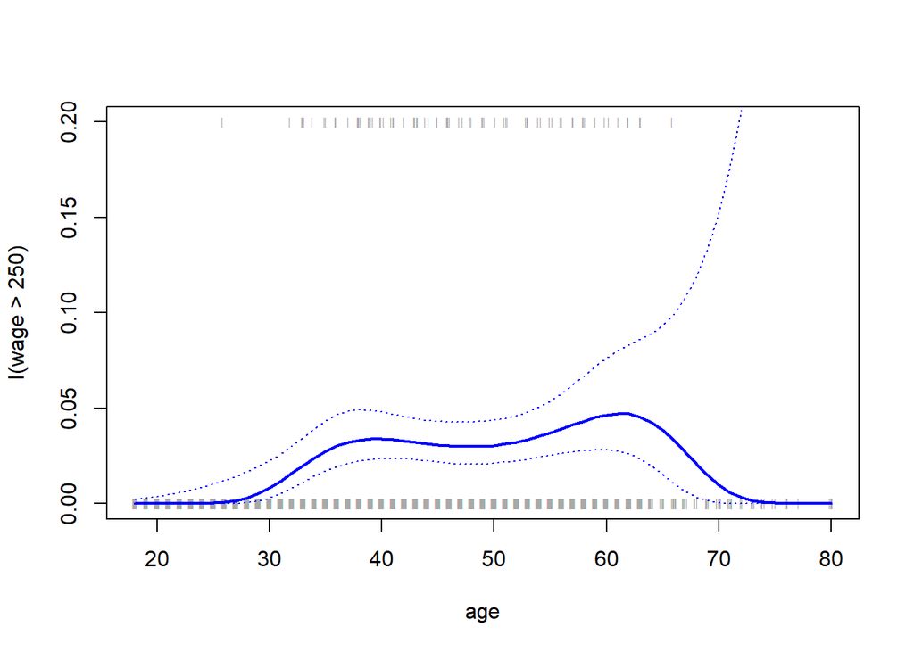

```r
plot(age ,I(wage >250),xlim=agelims ,type="n",ylim=c(0,.2))
points(jitter(age), I((wage >250)/5),cex=.5,pch ="|", col="darkgrey")
lines(age.grid ,pfit ,lwd=2, col ="blue")
matlines (age.grid ,se.bands ,lwd=1, col="blue",lty=3)
```

Here is a plot of the probability that someone of a certain age will make above $250,000. The gray spots on the top are observed ages where an individual makes above $250,000 while the gray spots on the bottom or those that do not. The dotted blue lines are the confidence interval while the solid blue line is the predicted probability of making above $250,000 for a give age from 18 to 80.

```r
table(cut(age ,4))
```

```
##
## (17.9,33.5]   (33.5,49]   (49,64.5] (64.5,80.1]
##         750        1399         779          72
```

```r
fit=lm(wage~cut(age ,4),data=Wage)
coef(summary (fit))
```

```
##                         Estimate Std. Error   t value     Pr(>|t|)
## (Intercept)            94.158392   1.476069 63.789970 0.000000e+00
## cut(age, 4)(33.5,49]   24.053491   1.829431 13.148074 1.982315e-38
## cut(age, 4)(49,64.5]   23.664559   2.067958 11.443444 1.040750e-29
## cut(age, 4)(64.5,80.1]  7.640592   4.987424  1.531972 1.256350e-01
```

The cut function equally divides the age into four bins. We use the cut points within the linear model to create categorical variables so we predict salary based on age bins.